# Week 2-2. Common distributions: Normal, Binomial, Poisson

< Back to Syllabus

### 1. Estimators

#### 1.1 Parameters and Estimators

Recall that

- **Parameter**: unknown object of interest
- **Estimator**: data-driven guess of the value of the parameter
  - e.g. Binomial distribution has **one unknown parameter**: **the probability of success, $\pi$**.
  - The other parameter, $n$, is usually dictated by the researcher in terms of the size of a sample that will be obtained.

### 2. Review Binomial Random Variable

- There are **four conditions** that characterize binomial data.
  - 1> The outcome or response takes on one and only one of two possibilities. This is a **binary outcome** or **binary response**.
    - The outcome of interest = **success**
    - The other = **failure**
    - Success does not necessarily mean that it is a ‘desirable’ outcome. For example, we may be interested in whether a patient dies or lives in hospital. In this case, we might denote the outcome death as a ‘success’ if it were the outcome of interest.
  - 2> The outcome is observed a known number of times. One observation of the outcome is sometimes called a **Bernoulli trial**. A binomial random variable is an observation of a set number, **$n$** of **Bernoulli trials**.
    - A **trial** can be something like an individual attempt or try such as a flip of a coin.
    - The outcome of interest = **heads** (maybe)
    - A **trial** could also be an individual and an outcome of interest is whether the individual tests positive for a disease.
  - 3> The chance, or probability, that a particular outcome occurs is the same for each trial.
    - If we are sampling individuals, they all come **from the same population** and have the **same chance of being created**.
    - If it is a test result, it assumes that the testing procedure is the same for each sample.
  - 4> The outcome of one trial must not be influenced by the outcomes of other trials. (**Independency**)
    - An example where this is not met if when testing for disease, there was contamination between the samples.
- Binomial distribution depends on **two parameters**.
  - **$n$**: the number of trials (or number of individuals)
  - **$\pi$**: the probability of a sucess in ONE trial
    - If $\pi$, the probability of success, is close to 1, then the number of successes out of $n$ trials will tend to be large, or closer to $n$.
    - If $\pi$, the probability of success, is near 0, $Y$ will tend to be closer to 0.
- Binomial random variable, **$Y$**: the count of the number of successes in $n$ trials
  - the values that Y can be are 0, 1, 2, …, n.

### 3. Estimate the value of $\pi$ for a binomial random variable.

- The mean of binomial random variable $Y$ with parameters $n$ and $\pi$ is $E(Y)=n\pi$.
- To estimate the **proportion of success** for a binomial random variable, we can use the **sample proportion** of the observed sample.
  - To estimate $\pi$, we would divide the observed number of successes, $y$, by $n$.

$$E\left(\frac{Y}{n}\right)=\pi$$

- So the estimate of $\pi$, which we will call $p$, is

$$p=\frac{y}{n}$$

where $y$ is the observed number of successes in the $n$ trials.

#### 3.1 Example: estimate the proportion of individuals who have diabetes

It is known that the proportion of adults in the US who have diabetes is 0.094 or 9.4%. If we take a random sample of 750 of US adults and determine the number who have diabetes, $Y$, then $Y$ has a binomial distribution with $n$=750 and $\pi$=0.094. Suppose we did not know the value of $\pi$, we would estimate it with the observed number of individuals out of the 750 who have diabetes, $y$ divided by 750; the estimate would be $p$ = $y$ / 750.

1> Let’s simulate this experiment by using the `R` function **`rbinom()`** to get a sample size 750 from the population

```r
(y <- rbinom(1, 750, 0.094))
```

```
## [1] 83
```

```r
(y1 <- rbinom(1, 750, 0.094))
```

```
## [1] 76
```

Perform a simulation where we get 5000 samples of size 750 each and for each sample, we compute the value of $p$.

- Use **`rbinom()`** and store the 5000 simulated estimates of $p$ in a vector called `props`. We then will take a look at the first 125 values in the vector.

```r
props <- rbinom(5000, 750, 0.094) / 750
round(props[1:125], 3)
```

```
##   [1] 0.096 0.084 0.097 0.113 0.092 0.079 0.104 0.103 0.109 0.096 0.092 0.104
##  [13] 0.095 0.103 0.077 0.105 0.092 0.093 0.089 0.087 0.076 0.087 0.079 0.109
##  [25] 0.105 0.091 0.101 0.089 0.103 0.100 0.119 0.080 0.092 0.096 0.116 0.091
##  [37] 0.103 0.083 0.079 0.089 0.083 0.088 0.071 0.108 0.089 0.103 0.087 0.085
##  [49] 0.083 0.080 0.075 0.085 0.088 0.099 0.109 0.121 0.095 0.096 0.083 0.092
##  [61] 0.072 0.091 0.081 0.103 0.091 0.105 0.100 0.095 0.105 0.092 0.089 0.099
##  [73] 0.084 0.112 0.092 0.093 0.087 0.112 0.093 0.087 0.109 0.096 0.091 0.095
##  [85] 0.092 0.089 0.103 0.116 0.101 0.088 0.104 0.089 0.101 0.093 0.107 0.092
##  [97] 0.080 0.091 0.079 0.095 0.079 0.093 0.096 0.109 0.093 0.077 0.077 0.103
## [109] 0.096 0.093 0.100 0.097 0.104 0.101 0.095 0.101 0.084 0.103 0.097 0.093
## [121] 0.109 0.085 0.093 0.100 0.093
```

- Looking at the values, they all seem relatively close to the real value of **0.094**.
- Looking at the data through the graph is better.

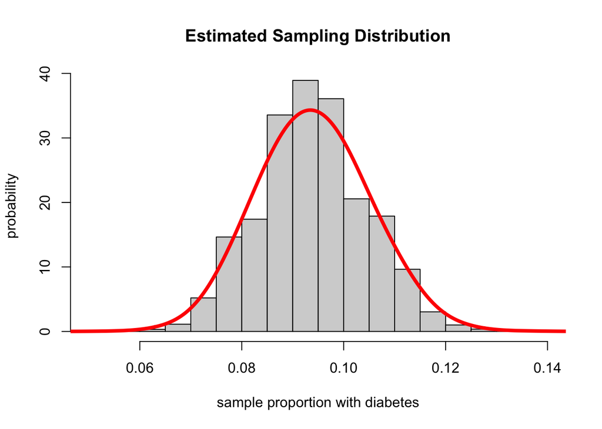

```r
hist(props,
    xlab = "sample proportion with diabetes",
    ylab = "probability",
    freq = FALSE,
    main = "Estimated Sampling Distribution")
lines(density(props,adjust=2.5),col="red",lwd=4)
```

- The plot shows both the histogram and the density plot.
  - We could use this information in our simulated sampling distribution to determine the likelihood of getting various estimates for the proportion of individuals with diabetes based on a random sample of size 750.

##### What is the probability of getting an estimate for the proportion with diabetes between 0.084 and 0.104, inclusive?

```r
sum((props >= 0.084 & props <= 0.104)) / 5000
```

```
## [1] 0.6804
```

> It would be quite likely to get estimates in this range. This can also be seen from **the sampling distribution for the estimated proportion**.

##### What is the probability of getting an estimate for the proportion with diabetes that is more than 0.02 from the true value?

> the interval is (0.094-0.02, 0.094+0.02) = (0.074, 0.114)

```r
(answer <- sum((props < 0.074 | props > 0.114 )) / 5000)
```

```
## [1] 0.0552
```

#### 3.2 Estimators as random variables

- a function of random variables is a random variable.
- Thus, **estimators** are **random variables**.
- As such, we can compute the **expected value** and the **variance** of the **estimator**.

#### 3.3 Mean and Variance of estimate the proportion of success for a binomial random variable

##### 1) mean

- The estimator of the probability of success for the binomial distribution is itself a **random variable**.
- The number of observed successes in the sample, $y$, is described by the random variable $Y$, which is binomial.
- So our estimator is the random variable, *Y/n*, we can compute its expected value.

$$E(p)=E\left(\frac{Y}{n}\right)=\frac{E(Y)}{n}=\frac{n \pi}{n}=\pi$$

- So the **expected value of the estimator** is in this case equal to the **true parameter value**.
  - The estimators that have this property are called **unbiased**.
- The **expected value of this estimator** does **NOT** depend on the **sample size** $n$ upon which the estimate is based.
  - It means that on average, the **estimate** will equal **the value we are trying to estimate**.

##### 2) variance

- The **variance of the estimator decreases as the sample size increases**.
  - In order to ensure that the estimate of the true proportion is closer to the true proportion, one needs a larger sample size.

> **We want estimators that have the mean as close as possible to the true value and smallest variance.**

### 4. Sampling distribution for the estimate of a binomial proportion

- A basic statistical fact is that **sample statistics** (e.g. the **sample proportion**, $p = y / n$ , where y is the number of successes in a sample of size n) vary from sample to sample.
- The key idea is that a statistic associated with a random sample is a random variable.
- We can relate the variability of a statistic based on a random sample to the variability of the random variable on which the statistic is based.

> The probability function (PMF or PDF) of a statistic is called the **`sampling distribution of the statistic`**.

#### 4.1 Characteristics of the **Sample Proportion**

- If a random variable $Y$ is binomial
  - with a probability of success of $\pi$,
  - the **sampling distribution of the sample proportion** (of samples of size $n$) :

  has population mean $\pi$ and population variance $\frac{\pi(1-\pi)}{n}$.

> **Standard error**: the standard deviation of the sampling distribution.
- Looking at the **sampling distribution of the sample proportion, $p$**, its shape is similar to a **binomial distribution**.
- If the binomial distribution of $Y$ with parameters $\pi$ and $n$ can only take the values of $y$ = 0, 1, 2, . . . , $n$, then the distribution of the sample proportion can only take on the values $p$ = 0/$n$(= 0), 1/$n$, 2/$n$, . . . , $n$/$n$(= 1).
- The probabilities map one-to-one with the probability

$$\begin{array}{c}\operatorname{Pr}(Y=0)=\operatorname{Pr}(p=0) \\ \operatorname{Pr}(Y=1)=\operatorname{Pr}(p=1 / n) \\ \operatorname{Pr}(Y=2)=\operatorname{Pr}(p=2 / n) \\ \operatorname{Pr}(Y=3)=\operatorname{Pr}(p=3 / n) \\ \ldots \\ \operatorname{Pr}(Y=n)=\operatorname{Pr}(p=1)\end{array}$$

- So **the sampling distribution for the sample proportion $p$=$y$ / $n$** has **binomial** probabilities but **with different outcome values**.

> If $Y$ has a binomial distribution with a probability of success of $\pi$, then the sample proportion $p$, based on a random sample of $n$ observations (or trials), has a binomial distribution with men $\pi$ and variance $\pi(1-\pi)$ /$n$.  
> In order to compute these values, we need to use **`binom()`** with $Y$ and $n$ to get the probabilities.

##### What is the probability of getting an estimate for the proportion with diabetes between 0.084 and 0.104, inclusive?

> First, we need to determine the $y$ values that corresponds to 0.084 and 0.104, respectively. $\operatorname{Pr}(63 \leq Y \leq 78)$

```r
(answer2 <- round(pbinom(78, 750, 0.094) - pbinom(62, 750, 0.094), 3))
```

```
## [1] 0.683
```

> Second, compare 0.683 to the below:

```r
sum((props >= 0.084 & props <= 0.104)) / 5000
```

```
## [1] 0.6804
```

##### What is the probability of getting an estimate for the proportion with diabetes that is more than 0.02 from the true value?

> - The interval is (0.094-0.02, 0.094+0.02) = (0.074, 0.114)
> - Pr($p$<0.074) + Pr($p$>0.114) To translate to the values for Y, we multiply the $p$ by 750. This results in $y=750\times0.074=55.5$ and $y=750\times0.114=85.5$. Thus, we want to use a binomial distribution to compute $Pr(Y<55.5)=Pr(Y\le 55)$ and compute $Pr(Y>85.5)=Pr(Y\ge86)$. Recall that to compute $Pr(Y\ge86)$ the relationship $Pr(Y\ge86)=1-Pr(Y\le85)$.

```r
(answer3 <- round(pbinom(55,750,0.094) + (1 - pbinom(85,750,0.094)), 3))
```

```
## [1] 0.06
```

> Compare 0.06 to the below:

```r
(answer4 <- sum((props < 0.074 | props > 0.114 )) / 5000)
```

```
## [1] 0.0552
```

> **The values from the simulated sampling distribution for $p$ yields values close to the values from the exact sampling distribution**.

< Back to Syllabus